# Serie2 computational Statistics

T.Watrigant

9 novembre 2017

# Exercices 3.1, 3.3, 3.10 et 3.15 traités en R

# Exercice 3.1

Intégrande du numérateur:

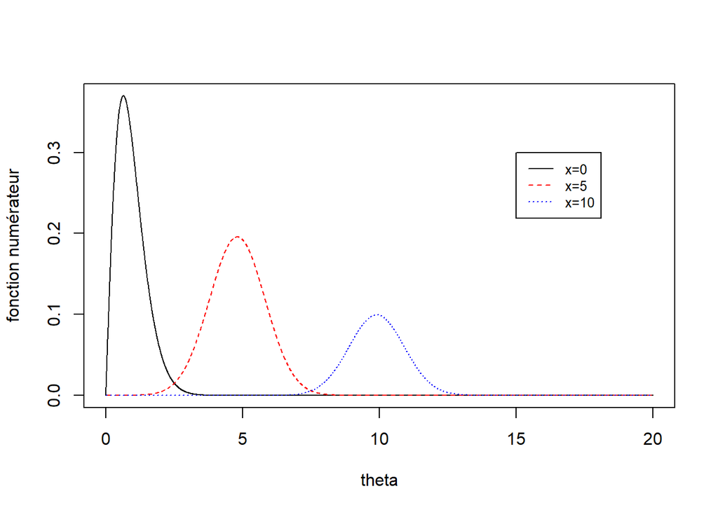

```r
x=0
fonction<-function(theta){(theta/(1+theta^2))*exp((-(x-theta)^2)/2)}
theta<-c(0:4000)/200
plot(x=theta,y=fonction(theta),type="l",ylab="fonction numérateur")

x=5
lines(x=theta,y=fonction(theta),type="l",col="red",lty=2)

x=10
lines(x=theta,y=fonction(theta),type="l",col="blue",lty=3)

legend(15, 0.3, legend=c("x=0", "x=5","x=10"),col=c("black","red", "blue"), lty=1:3, cex=0.8)
```

Intégrande du dénominateur:

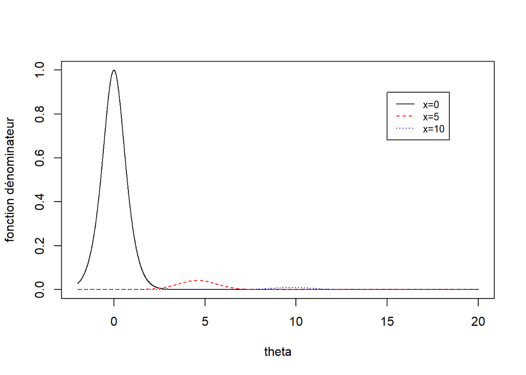

```r
x=0
fonction1<-function(theta){(1/(1+theta^2))*exp((-(x-theta)^2)/2)}
theta<-c(-400:4000)/200
plot(x=theta,y=fonction1(theta),type="l",ylab="fonction dénominateur")

x=5
lines(x=theta,y=fonction1(theta),type="l",col="red",lty=2)

x=10
lines(x=theta,y=fonction1(theta),type="l",col="blue",lty=3)

legend(15, 0.9, legend=c("x=0", "x=5","x=10"),col=c("black","red", "blue"), lty=1:3, cex=0.8)
```

```r
x=5
n=1000
theta=rnorm(n,x,1)
deltan<-c()
deltad<-c()
deltan[1]=(theta[1]/(1+theta[1]^2))
deltad[1]=(1/(1+theta[1]^2))

for (k in 2:n){
  deltan[k]=deltan[k-1]+(theta[k]/(1+theta[k]^2))
}

for (k in 2:n){
  deltad[k]=deltad[k-1]+(1/(1+theta[k]^2))
}

integral=deltan[n]/deltad[n]


print(paste0("Valeur de l'intégrale selon la méthode Monte-Carlo (x=5)=" , integral))
```

```
## [1] "Valeur de l'intégrale selon la méthode Monte-Carlo (x=5)=4.52161005063754"
```

```r
deltanf=1/n*deltan[n]

## calcul de la variance du numérateur
var1<-c()
var1[1]=1/(n-1)*((deltan[1]-deltanf)^2)
for(k in  2:n){
  var1[k]=var1[k-1]+(1/(n-1))*((deltan[k]-deltanf)^2)
}

deltadf=1/n*deltad[n]
## calcul de la variance du dénominateur
var2<-c()
var2[1]=1/(n-1)*((deltad[1]-deltadf)^2)
for(k in  2:n){
  var2[k]=var2[k-1]+(1/(n-1))*((deltad[k]-deltadf)^2)
}


"Pour avoir un intervalle de confiance de 95% il faut encadrer la valeur de l'intégrale par (+/-) 1.96 fois la variance plus la valeur empirique puisque qu'avec la méthode de Monte Carlo, on peut se ramener à un loi normale de moyenne nulle et variance égale à 1.  "
```

```
## [1] "Pour avoir un intervalle de confiance de 95% il faut encadrer la valeur de l'intégrale par (+/-) 1.96 fois la variance plus la valeur empirique puisque qu'avec la méthode de Monte Carlo, on peut se ramener à un loi normale de moyenne nulle et variance égale à 1.  "
```

```r
bornesup1=deltanf+1.96*sqrt(var1[n]/sqrt(n))
borneinf1=deltanf-1.96*sqrt(var1[n]/sqrt(n))

bornesup2=deltadf+1.96*sqrt(var2[n]/sqrt(n))
borneinf2=deltadf-1.96*sqrt(var2[n]/sqrt(n))

"Une fois que l'on a un intervalle de confiance pour le numérateur et le dénominateur, on obtient la borne inférieure de l'intervalle de confiance en prenant la borne inférieure du numérateur divisée par la borne supérieure du dénominateur afin d'obtenir la valeur la plus petite de l'intervalle de confiance. On fait de même pour la borne supérieure. On obtient alors la précision en regardant l différence de ces deux bornes."
```

[output not shown]

```r
precision=abs(bornesup1/borneinf2-borneinf1/bornesup2)

"pour 1000 itérations, on a une précision de l'ordre de 0.01, il faut donc augmenter le nombre d'itérations pour avoir une précision sur le troisième digit"
```

```
## [1] "pour 1000 itérations, on a une précision de l'ordre de 0.01, il faut donc augmenter le nombre d'itérations pour avoir une précision sur le troisième digit"
```

```r
n=100000

theta=rnorm(n,x,1)
deltan<-c()
deltad<-c()
deltan[1]=(theta[1]/(1+theta[1]^2))
deltad[1]=(1/(1+theta[1]^2))

for (k in 2:n){
  deltan[k]=deltan[k-1]+(theta[k]/(1+theta[k]^2))
}

for (k in 2:n){
  deltad[k]=deltad[k-1]+(1/(1+theta[k]^2))
}

integral=deltan[n]/deltad[n]

deltanf=1/n*deltan[n]

## calcul de la variance du numérateur
var1<-c()
var1[1]=1/(n-1)*((deltan[1]-deltanf)^2)
for(k in  2:n){
  var1[k]=var1[k-1]+(1/(n-1))*((deltan[k]-deltanf)^2)
}



deltadf=1/n*deltad[n]
## calcul de la variance du dénominateur
var2<-c()
var2[1]=1/(n-1)*((deltad[1]-deltadf)^2)
for(k in  2:n){
  var2[k]=var2[k-1]+(1/(n-1))*((deltad[k]-deltadf)^2)
}


bornesup1=deltanf+1.96*sqrt(var1[n]/sqrt(n))
borneinf1=deltanf-1.96*sqrt(var1[n]/sqrt(n))

bornesup2=deltadf+1.96*sqrt(var2[n]/sqrt(n))
borneinf2=deltadf-1.96*sqrt(var2[n]/sqrt(n))

precision=abs(bornesup1/borneinf2-borneinf1/bornesup2)

"en passant à 100000 itération, on a une précision sur le troisième digit"
```

```
## [1] "en passant à 100000 itération, on a une précision sur le troisième digit"
```

On voit que pour avoir une précision de trois digits il faut avoir fait de nombreuses itérations de l’ordre de 100 000, ce qui explique le théorème des grands nombres s’appliquent vraiment quand le nombre d’itérations est très important.

Convergence du numérateur:

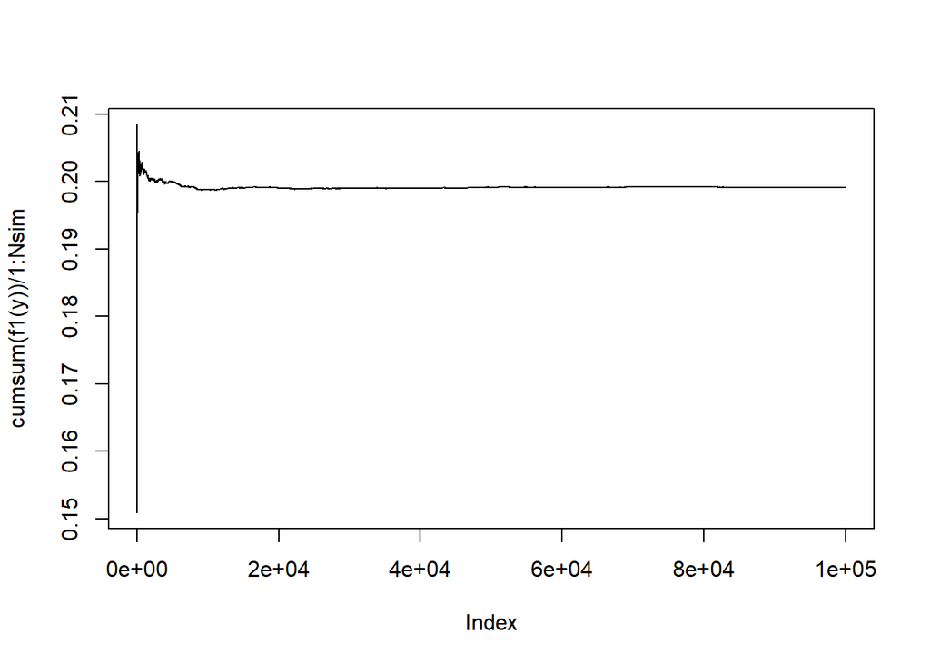

```r
f1 = function(y){
    return(y/(1+y^2))
    }


Nsim=10^5
y=rnorm(Nsim,x,1)

plot(cumsum(f1(y))/1:Nsim,type="l")
```

Convergence du dénominateur

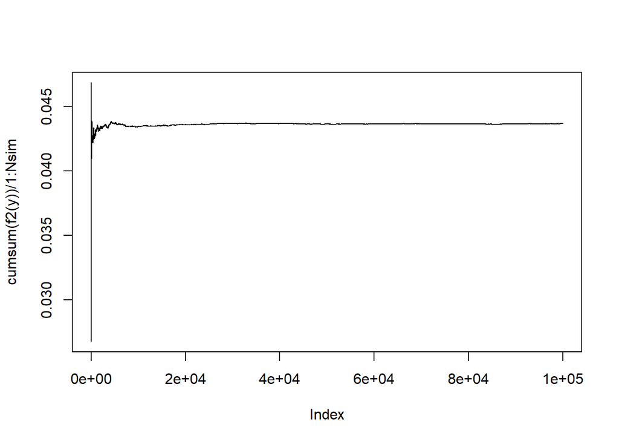

```r
f2 = function(y){
    return(1/(1+y^2))
    }


Nsim=10^5
y=rnorm(Nsim,x,1)

plot(cumsum(f2(y))/1:Nsim,type="l")
```

# EXERCICE 3.3

## Loi normale standard

```r
n=1000
Z=rnorm(n,0,1)
rho<-c()
# mise en place de la méthode de Monte Carlo
if(Z[1]>2.5)  rho[1]=1 else rho[1]=0
for (k in 2:n){
  if(Z[k]>2.5) rho[k]=rho[k-1]+1  else rho[k]=rho[k-1]
}

rhof=(1/n)*rho[n]
print(rhof)
```

```
## [1] 0.003
```

```r
n=10000
Z=rnorm(n,0,1)
rho<-c()
# mise en place de la méthode de Monte Carlo
if(Z[1]>2.5)  rho[1]=1 else rho[1]=0
for (k in 2:n){
  if(Z[k]>2.5) rho[k]=rho[k-1]+1  else rho[k]=rho[k-1]
}

rhof=(1/n)*rho[n]
print(rhof)
```

```
## [1] 0.0059
```

```r
"pour obtenir 3 digits de précision il faut mettre en place 10 000 itérations avec la méthode de Monte Carlo"
```

```
## [1] "pour obtenir 3 digits de précision il faut mettre en place 10 000 itérations avec la méthode de Monte Carlo"
```

## Loi Gamma (1,1)

```r
n=10000
Z1=rgamma(n,1,1)
rhog<- c()
# mise en place de la méthode de Monte Carlo
if(Z1[1]>5.3)  rhog[1]=1 else rhog[1]=0
for (k in 2:n){
  if(Z1[k]>5.3) rhog[k]=rhog[k-1]+1  else rhog[k]=rhog[k-1]
}
rhogf=(1/n)*rhog[n]
print(rhogf)
```

```
## [1] 0.005
```

```r
"on retrouve environ le 0.005  de l'énoncé (cela dépend du tirage au niveau du rgamma). Mais pour obtenir une valeur globalement proche de 0.005, il a fallu faire 10 000 itérations (sinon même pour 1000 itérations la valeur est trop instable, elle peut aller de 0.002 à 0.008).Ce qui montre que la méthode de Monte Carlo n'est pas toujours adaptée surtout dans les cas l'évènement que l'on cherche a une probabilité très faible."
```

[output not shown]

```r
"pour trouver la valeur exacte de 0.995, on va augmenter le nombre d'itérations pour avoir une meilleure précision sur les valeurs"
```

```
## [1] "pour trouver la valeur exacte de 0.995, on va augmenter le nombre d'itérations pour avoir une meilleure précision sur les valeurs"
```

```r
n=100000
Z1=rgamma(n,1,1)
rhog<- c()
for(i in 520:530){
  if(Z1[1]>i/100)  rhog[1]=1 else rhog[1]=0

  for (k in 2:n){
    if(Z1[k]>i/100) rhog[k]=rhog[k-1]+1  else rhog[k]=rhog[k-1]
  }
  rhogf=(1/n)*rhog[n]
  print (i/100)
  print(rhogf)
}
```

```
## [1] 5.2
## [1] 0.00549
## [1] 5.21
## [1] 0.00547
## [1] 5.22
## [1] 0.00543
## [1] 5.23
## [1] 0.00538
## [1] 5.24
## [1] 0.00533
## [1] 5.25
## [1] 0.00527
## [1] 5.26
## [1] 0.00525
## [1] 5.27
## [1] 0.00521
## [1] 5.28
## [1] 0.00519
## [1] 5.29
## [1] 0.00515
## [1] 5.3
## [1] 0.0051
```

```r
"ici, on a fait une première approximation afin de faire un encadrement des valeurs possibles pour limiter le nombre d'itérations à effectuer et avoir un résultat intermédiaire (20 itérations en tout au lieu de 100)"
```

```
## [1] "ici, on a fait une première approximation afin de faire un encadrement des valeurs possibles pour limiter le nombre d'itérations à effectuer et avoir un résultat intermédiaire (20 itérations en tout au lieu de 100)"
```

```r
n=100000
Z1=rgamma(n,1,1)
rhog<- c()
for(i in 5270:5280){
  if(Z1[1]>i/1000)  rhog[1]=1 else rhog[1]=0

  for (k in 2:n){
    if(Z1[k]>i/1000) rhog[k]=rhog[k-1]+1  else rhog[k]=rhog[k-1]
  }
  rhogf=(1/n)*rhog[n]
  print (i/1000)
  print(rhogf)
}
```

```
## [1] 5.27
## [1] 0.00497
## [1] 5.271
## [1] 0.00496
## [1] 5.272
## [1] 0.00496
## [1] 5.273
## [1] 0.00496
## [1] 5.274
## [1] 0.00496
## [1] 5.275
## [1] 0.00496
## [1] 5.276
## [1] 0.00496
## [1] 5.277
## [1] 0.00493
## [1] 5.278
## [1] 0.00493
## [1] 5.279
## [1] 0.00492
## [1] 5.28
## [1] 0.00491
```

# EXERCICE 3.10

```r
# ici on a la densité d'une loi normale (0,1)
n=10
"Pour n=10"
```

```
## [1] "Pour n=10"
```

```r
Z=rnorm(n,0,1)
"Monte Carlo"
```

```
## [1] "Monte Carlo"
```

```r
rho<-c()
if(Z[1]>1)  rho[1]=1 else rho[1]=0
for (k in 2:n){
  if(Z[k]>1) rho[k]=rho[k-1]+1  else rho[k]=rho[k-1]
}
rhof=(1/n)*rho[n]
rhoinf<-c()
if(Z[1]>2)  rhoinf[1]=1 else rhoinf[1]=0
for (k in 2:n){
  if(Z[k]>2) rhoinf[k]=rhoinf[k-1]+1  else rhoinf[k]=rhoinf[k-1]
}
rhoinff=(1/n)*rhoinf[n]
rhofinal=rhof-rhoinff
print(rhofinal)
```

```
## [1] 0.1
```

```r
"IS"
```

```
## [1] "IS"
```

```r
w <- function(x) dunif(x, 1, 2)/dexp(x,rate=1)
f <- function(x) exp(-0.5*(x)^2)/(sqrt(2*pi))
X <- rexp(n,rate=1)
Y <- w(X)*f(X)
c(mean(Y),var(Y))
```

```
## [1] 0 0
```

```r
n=1000000
Z=rnorm(n,0,1)
"Pour n=1000000"
```

```
## [1] "Pour n=1000000"
```

```r
"Monte Carlo"
```

```
## [1] "Monte Carlo"
```

```r
rho<-c()
if(Z[1]>1)  rho[1]=1 else rho[1]=0
for (k in 2:n){
  if(Z[k]>1) rho[k]=rho[k-1]+1  else rho[k]=rho[k-1]
}
rhof=(1/n)*rho[n]
rhoinf<-c()
if(Z[1]>2)  rhoinf[1]=1 else rhoinf[1]=0
for (k in 2:n){
  if(Z[k]>2) rhoinf[k]=rhoinf[k-1]+1  else rhoinf[k]=rhoinf[k-1]
}
rhoinff=(1/n)*rhoinf[n]
rhofinal=rhof-rhoinff
print(rhofinal)
```

```
## [1] 0.135822
```

```r
"IS"
```

```
## [1] "IS"
```

```r
w <- function(x) dunif(x, 1, 2)/dexp(x,rate=1)
f <- function(x) exp(-0.5*(x)^2)/(sqrt(2*pi))
X <- rexp(n,rate=1)
Y <- w(X)*f(X)
c(mean(Y),var(Y))
```

```
## [1] 0.13604980 0.06228407
```

```r
# on retrouve la valeur de l'intégrale au niveau de la moyenne des Y qui utilise la méthode Importance Sampling
```

L’importance sampling a peu de restriction sur le choix du candidat, g qui peut être choisi pour des distributions qui sont faciles à simuler ou du moins efficace pour approximer l’intégrale. De plus, le même échantillon (produit de g) peut être utilisé à plusieurs reprises, non seulement pour différentes fonctions h mais aussi pour différente densité f.

# Exercice 3.15

```r
#on prend un nombre faible d'itérations pour avoir une première approximation
n=10
Z=rnorm(n,0,1)
rho<-c()
#Monte Carlo
if(Z[1]>2.5)  rho[1]=1 else rho[1]=0
for (k in 2:n){
  if(Z[k]>2.5) rho[k]=rho[k-1]+1  else rho[k]=rho[k-1]
}
rhof=(1/n)*rho[n]
```

$$\begin{aligned}
P(X > 2.5) & = \int_{2.5}^{+\infty} f_X(x) dx \\
& = \int_{\phi^{-1}(2.5)}^{\phi^{-1}(+\infty)} f_X(\phi(u))~\phi'(u)~du \\
& = - \int_0^{1/2.5} \frac{1}{\sqrt{2\pi}} e^{-1/2u^2} \times \frac{-1}{u^2}~du \\
& = \int_0^{1/2.5} \frac{e^{-1/2u^2}}{2.5u^2\sqrt{2\pi}} \times 2.5~du\\
\end{aligned}$$
Après avoir fait le changement de variable dans l’intégrale, on peut appliquer l’importance sampling comme suit:

```r
# Importance Sampling
g <- function(u) exp(-1/(2*u^2))/(2.5*u^2*sqrt(2*pi))
U <- runif(n,0,1/2.5)
A=mean( g(U) )

#calcul de la "vraie" valeur de la probabilité
f <- function(x) exp(-0.5*(x^2))/(sqrt(2*pi))
CV=integrate(f,2.5,Inf)$value

# calcul de la précision pour les deux méthodes
lost1=CV-A
print(lost1/CV)
```

```
## [1] -0.1800244
```

```r
lost2=CV-rhof
print(lost2/CV)
```

```
## [1] 1
```

```r
# on va maintenant le nombre d'itérations pour voir laquelle des méthodes converge le plus vite
n=100000
Z=rnorm(n,0,1)
rho<-c()
#Monte Carlo
if(Z[1]>2.5)  rho[1]=1 else rho[1]=0
for (k in 2:n){
  if(Z[k]>2.5) rho[k]=rho[k-1]+1  else rho[k]=rho[k-1]
}
rhof=(1/n)*rho[n]

# Importance Sampling
g <- function(u) exp(-1/(2*u^2))/(2.5*u^2*sqrt(2*pi))
U <- runif(n,0,1/2.5)
A=mean( g(U) )

# calcul de la précision pour les deux méthodes
lost1=CV-A
print(lost1/CV)
```

```
## [1] 0.001052108
```

```r
lost2=CV-rhof
print(lost2/CV)
```

```
## [1] 0.03698514
```

L’avantage de l’importance sampling est qu’il permet d’avoir une première approximation très rapidement en peu d’itération alors que dans le cas de la méthode de Monte-Carlo un nombre important (voire très important) peut être nécessaire surtout quand l’évènement se produit rarement voire très rarement.<> La précision peut être déjà très bonne (3 digits de précision) avec 100 000 itérations pour l’importance sampling alors qu’il en faut plus avec la méthode de Monte Carlo avec au moins 1 000 000 mais la précision est très instable avec la méthode de Monte Carlo (dans certains cas la précision est mieux que l’importance sampling, cela dépend du tirage pour la loi normale). Cette instabilité (dû au tirage) se retrouve aussi au niveau de l’importance sampling mais dans ce cas, on a globlement le même résultat de précision. Ce qui implique un temps de calcul largement augmenté d’avoir un rapport 10 voire 100 pour le nombre d’itération.<> La convergence selon la méthode d’importance sampling peut être plus ou moins rapide selon la fonction g que l’on choisit. Cette fonction g peut converger rapidement pour le calcul de l’intégrale d’une fonction f et être plus lente pour une autre fonction f’.

## Loi Gamma (1,1)

```r
#on prend un nombre faible d'itérations pour avoir une première approximation
n=10
Z1=rgamma(n,1,1)
rhog<- c()
# Monte Carlo
if(Z1[1]>5.3)  rhog[1]=1 else rhog[1]=0
for (k in 2:n){
  if(Z1[k]>5.3) rhog[k]=rhog[k-1]+1  else rhog[k]=rhog[k-1]
}
rhogf=(1/n)*rhog[n]
```

$$\begin{aligned}
P(X > 5.3) & = \int_{5.3}^{+\infty} f_X(x) dx \\
& = \int_{\phi^{-1}(5.3)}^{\phi^{-1}(+\infty)} f_X(\phi(u))~\phi'(u)~du \\
& = - \int_0^{1/5.3} \frac{(1/u)^{k-1}exp(\frac{-1}{u\theta})}{5.3\Gamma(k)\theta^k} 5.3 \times \frac{-1}{u^2}~du \\
& = \int_0^{1/5.3} \frac{(1/u)^{k-1}exp(\frac{-1}{u\theta})}{5.3\Gamma(k)\theta^ku^2} 5.3 ~du \\
\\
ici\; k=1\; et\; \theta=1\\
\\
& = \int_0^{1/5.3} \frac{exp(\frac{-1}{u\theta})}{5.3u^2} 5.3 ~du \\
\end{aligned}$$
Après avoir fait le changement de variable dans l’intégrale, on peut appliquer l’importance sampling comme suit:

```r
# Importance Sampling
g <- function(u) exp(-1/u)/(5.3*(u^2))
U <- runif(n,0,1/5.3)
A=mean( g(U) )

#calcul de la "vraie" valeur de la probabilité
f <- function(x) exp(-x)
CV=integrate(f,5.3,Inf)$value


# calcul de la précision pour les deux méthodes
lost1=CV-A
print(lost1/CV)
```

```
## [1] 0.1072691
```

```r
lost2=CV-rhogf
print(lost2/CV)
```

```
## [1] 1
```

```r
# on va maintenant le nombre d'itérations pour voir laquelle des méthodes converge le plus vite
n=100000
Z1=rgamma(n,1,1)
rhog<- c()
# Monte Carlo
if(Z1[1]>5.3)  rhog[1]=1 else rhog[1]=0
for (k in 2:n){
  if(Z1[k]>5.3) rhog[k]=rhog[k-1]+1  else rhog[k]=rhog[k-1]
}
rhogf=(1/n)*rhog[n]

# Importance Sampling
g <- function(u) exp(-1/u)/(5.3*(u^2))
U <- runif(n,0,1/5.3)
A=mean( g(U) )

# calcul de la précision pour les deux méthodes
lost1=CV-A
print(lost1/CV)
```

```
## [1] -0.005751585
```

```r
lost2=CV-rhogf
print(lost2/CV)
```

```
## [1] -0.02973143
```

Dans ce cas, il faut environ 100 000 itérations pour être suffisament précis pour l’importance sampling et beaucoup plus pour la méthode de Monte Carlo (de l’ordre 1 000 000 itérations pour avoir dans la plupart des cas (dépend du tirage) une précision de trois digits).